# Cheese Analysis

## Goals of this Notebook

- Look for trends in data
- Answer questions and find averages
- Create visualizations

I want to explore my data by answering the following questions:

### Price Questions:

- Which year had the highest average cheese price? Which had the lowest?
- Which year had the highest average prices after adjusting for inflation (in 2021 dollars)? Which had the lowest?
- In which month was the price of cheese the highest, on average (inflation adjusted)?
- What were the 2021 prices for each type of cheese?
- What were the average 2021 cheese prices for each month?
- What were the average 2021 cheese prices for each month?

### Storage Questions:

- Which year had the highest cheese storage holdings, on average? Which had the lowest?

### Visualizations:

## About the data

This is [USDA](http://rmarkdown.rstudio.com) price data on domestic cheeses that I’ve collected, cleaned and adjusted for inflation.

Storage holdings data is in units of pounds. The storage holding data comes from the USDA National Agricultural Statistics Service [Cold Storage Report](https://quickstats.nass.usda.gov/results/172E17CF-AD11-37D8-949A-0624FA6A9CD0).

## Setup

```r
library(tidyverse)
library(lubridate)
library(dplyr)
library(scales)
library(ggthemes)
```

## Import data

I’m importing my cleaned data here.

```r
chs_clean <- readRDS("data-processed/01-cleaning.rds")
storage_clean <- readRDS("data-processed/01-storage.rds")
```

### Create average price column

Right now each row of my data has a corresponding high and low price for each week. I’ll want a column that takes the average of those two prices for each week so I can get yearly averages.

```r
chs_with_avg <- chs_clean |>
  mutate(
    total_avg_price = (high_price + low_price)/2,
    total_price_adj = (adj_high_price + adj_low_price)/2
)

chs_with_avg |> glimpse()
```

```
## Rows: 22,366
## Columns: 10
## $ date            <date> 2000-12-25, 2000-12-25, 2000-12-25, 2000-12-25, 2000-…
## $ region          <chr> "WISCONSIN", "MIDWEST", "MIDWEST", "WISCONSIN", "WISCO…
## $ high_price      <dbl> 2.1150, 1.1925, 1.1450, 1.4800, 2.6850, 1.7375, 2.1150…
## $ low_price       <dbl> 1.4700, 1.1425, 1.1325, 1.3325, 2.0950, 1.4700, 1.6700…
## $ type            <chr> "CHEDDAR", "CHEDDAR", "CHEDDAR", "PROCESS AMERICAN", "…
## $ yr              <dbl> 2000, 2000, 2000, 2000, 2000, 2000, 2000, 2000, 2000, …
## $ adj_high_price  <dbl> 3.328484, 1.876699, 1.801945, 2.329152, 4.225523, 2.73…
## $ adj_low_price   <dbl> 2.313415, 1.798011, 1.782274, 2.097024, 3.297009, 2.31…
## $ total_avg_price <dbl> 1.79250, 1.16750, 1.13875, 1.40625, 2.39000, 1.60375, …
## $ total_price_adj <dbl> 2.820949, 1.837355, 1.792109, 2.213088, 3.761266, 2.52…
```

### Create month column

I also need to create a month column.

```r
chs_mnths <- chs_with_avg |>
  mutate(month_nm = month(date, label = TRUE)) #makes a month column
```

## Price Data Analysis

### Which year had the highest average total cheese prices, not adjusted for inflation? Which had the lowest?

I’ll group by year, which will put all the rows for each year together. Then I’ll use the sum(mean) function to get the average of the total price column I just created for each year.

```r
chs_with_avg |>
  group_by(yr) |>
  summarize(
    total_yr_price = mean(total_avg_price)
) |>
  arrange(total_yr_price |> desc())
```

| yr | total_yr_price |
| --- | --- |
| 2014 | 2.807010 |
| 2022 | 2.790400 |
| 2020 | 2.600549 |
| 2013 | 2.513577 |
| 2011 | 2.513178 |
| 2012 | 2.469476 |
| 2008 | 2.462777 |
| 2021 | 2.412623 |
| 2019 | 2.395060 |
| 2015 | 2.309112 |

[output cut: 13 more lines]

2014 had the highest average cheese price, not adjusted for inflation, with all cheese packages averaging a price of $2.81 per pound in that years dollars.

2000 had the lowest average total cheese price in my data, which was not adjusted for inflation, with an average minimum price of $1.65 per pound.

### Which year had the highest cheese prices in 2021 dollars? Which had the lowest?

I’ll use the same logic here to find the highest total adjusted prices by year, but I’ll sum the adjusted column instead.

```r
chs_with_avg |>
  group_by(yr) |>
  summarize(
    adj_yr_price = mean(total_price_adj)
) |>
  arrange(adj_yr_price |> desc())
```

| yr | adj_yr_price |
| --- | --- |
| 2014 | 3.213771 |
| 2008 | 3.099919 |
| 2004 | 3.051930 |
| 2011 | 3.028329 |
| 2007 | 2.951292 |
| 2013 | 2.923517 |
| 2012 | 2.914756 |
| 2001 | 2.890023 |
| 2005 | 2.793792 |
| 2010 | 2.752889 |

[output cut: 13 more lines]

2014 still had the highest total cheese prices after adjusting for inflation. The average price was 3.21 dollars per pound in 2021 dollars.

The second highest year changed after adjusting for inflation, from 2022 with 2.79 dollars per pound to 2008 with 3.10 dollars per pound.

2018 had the lowest total cheese prices after adjusting for inflation, with an average price of 2.35 dollars per pound.

### In which month was the price of cheese the highest, on average?

I’ll group by year and month, then month again to get the monthly average for all years.

```r
chs_mnths |>
  group_by(yr, month_nm) |> #group by both year and month first
  summarize(
   average_yearly_price = mean(total_price_adj)
) |>
  group_by(month_nm) |>
  summarize(
    average_monthly_price = mean(average_yearly_price) #taking the average of the yearly average for each month
) |>
  arrange(average_monthly_price |> desc()
)
```

```
## argument.
```

| month_nm | average_monthly_price |
| --- | --- |
| Oct | 2.828003 |
| Sep | 2.826005 |
| Nov | 2.783293 |
| Aug | 2.776531 |
| Jul | 2.761875 |
| Jun | 2.741942 |
| Dec | 2.723755 |
| May | 2.685403 |
| Apr | 2.657829 |
| Mar | 2.638441 |

[output cut: 2 more lines]

October saw the highest average cheese prices in our data, with an average price of 2.83 dollars per pound in 2021 dollars.

### 2021 prices

I want to look at 2021 prices for each type of cheese.

```r
chs_mnths |>
  filter(yr == 2021) |>
  group_by(type) |> #group by both month and type
  summarize(
   average_price = mean(total_avg_price)
) |>
  arrange(average_price |> desc()
)
```

| type | average_price |
| --- | --- |
| SWISS | 3.518670 |
| BLUE | 2.880697 |
| MOZZARELLA | 2.349567 |
| MUENSTER | 2.307067 |
| BRICK | 2.289567 |
| MONTEREY JACK | 2.158293 |
| CHEDDAR | 2.119255 |
| PROCESS AMERICAN | 1.843670 |

Swiss was the most expensive type of cheese on average in 2021 with an average price of 3.52 dollars per pound. Process American cheese was the least expensive that year, with an average price of 1.84 dollars per pound.

Now I want to look at total 2021 prices by month. I’ll filter to 2021 and then group by month.

```r
chs_mnths |>
  filter(yr == 2021) |>
  group_by(month_nm) |> #group by both month and type
  summarize(
   average_monthly_price = mean(total_avg_price)
) |>
  arrange(average_monthly_price |> desc()
)
```

| month_nm | average_monthly_price |
| --- | --- |
| Dec | 2.541103 |
| Oct | 2.507500 |
| Jan | 2.485919 |
| Sep | 2.446765 |
| Nov | 2.438971 |
| Aug | 2.434118 |
| Apr | 2.414301 |
| Feb | 2.377996 |
| Jul | 2.376360 |
| May | 2.368735 |

[output cut: 2 more lines]

December 2021 saw the highest average total cheese price for that year, with an average price of 2.54 per pound.

### 2022 prices

Now I want to find the monthly average prices for this year, not adjusted for inflation.

```r
thisyear_price <- chs_mnths |>
  filter(yr == 2022) |>
  group_by(date) |>
  summarize(avg_price = mean(total_avg_price))

thisyear_price
```

| date | avg_price |
| --- | --- |
| 2022-01-03 | 2.597059 |
| 2022-01-10 | 2.692647 |
| 2022-01-17 | 2.692794 |
| 2022-01-24 | 2.587794 |
| 2022-01-31 | 2.506176 |
| 2022-02-07 | 2.600882 |
| 2022-02-14 | 2.631176 |
| 2022-02-21 | 2.685735 |
| 2022-02-28 | 2.693382 |
| 2022-03-07 | 2.724118 |

[output cut: 35 more lines]

### Swiss prices by year

I want to look at just Swiss prices, so I’ll filter by data to Swiss and look at means again.

```r
chs_clean |>
  filter(type == "SWISS") |>
  group_by(yr) |>
  summarize(
    yrly_adj_high_price = mean(adj_high_price),
    yrly_adj_low_price = mean(adj_low_price)
) |>
  arrange(yrly_adj_high_price |> desc())
```

| yr | yrly_adj_high_price | yrly_adj_low_price |
| --- | --- | --- |
| 2014 | 4.399594 | 4.067570 |
| 2008 | 4.331974 | 3.718394 |
| 2011 | 4.269066 | 3.792945 |
| 2022 | 4.223994 | 3.099634 |
| 2010 | 4.113794 | 3.471930 |
| 2000 | 4.082674 | 3.407702 |
| 2009 | 4.071873 | 3.290642 |
| 2013 | 4.067221 | 3.729925 |
| 2012 | 4.054964 | 3.668600 |
| 2001 | 4.002011 | 3.483506 |

[output cut: 13 more lines]

### Muenster prices by year

I want to look at Muenster high and low prices, because it’s my mom’s favorite kind of cheese.

```r
chs_clean |>
  filter(type == "MUENSTER") |>
  group_by(yr) |>
  summarize(
    yrly_adj_high_price = mean(adj_high_price),
    yrly_adj_low_price = mean(adj_low_price)
) |>
  arrange(yr |> desc())
```

| yr | yrly_adj_high_price | yrly_adj_low_price |
| --- | --- | --- |
| 2022 | 2.631168 | 2.223456 |
| 2021 | 2.500817 | 2.113317 |
| 2020 | 2.927262 | 2.521495 |
| 2019 | 2.720408 | 2.310108 |
| 2018 | 2.522964 | 2.107559 |
| 2017 | 2.653877 | 2.266892 |
| 2016 | 2.644150 | 2.248942 |
| 2015 | 2.724349 | 2.322569 |
| 2014 | 3.313670 | 2.901503 |
| 2013 | 2.950311 | 2.531599 |

[output cut: 13 more lines]

2014 saw the highest Muenster high prices after adjusting for inflation. That’s the only year where the high price surpassed 3 dollars per pound.

## Storage holdings analysis

### Which year had the highest cheese storage holdings, on average? Which had the lowest?

```r
storage_yrly <- storage_clean |>
  filter(data_item == "CHEESE, NATURAL, COLD STORAGE, CHILLED - STOCKS, MEASURED IN LB") |>
  group_by(year) |>
  summarize(avg_yrly_holding = mean(value)) |>
  arrange(year |> desc())

storage_yrly
```

| year | avg_yrly_holding |
| --- | --- |
| 2022 | 1483438000 |
| 2021 | 1442371917 |
| 2020 | 1387009083 |
| 2019 | 1364191667 |
| 2018 | 1355484000 |
| 2017 | 1285667917 |
| 2016 | 1218020000 |
| 2015 | 1120493667 |
| 2014 | 1028576583 |
| 2013 | 1080855917 |

[output cut: 13 more lines]

2022 had the highest average cheese stocks, with over 1.48 billion pounds of cheese stored by the U.S. government.

2001 had the lowest average storage holdings, with over 704 million.

### Which month, on average, sees the highest cheese storage holdings?

```r
storage_monthly <- storage_clean |>
  filter(
    data_item == "CHEESE, NATURAL, COLD STORAGE, CHILLED - STOCKS, MEASURED IN LB"
) |>
  group_by(month_use) |>
  summarize(avg_storage = mean(value)) |>
  arrange(avg_storage |> desc())

storage_monthly
```

| month_use | avg_storage |
| --- | --- |
| Jul | 1089241913 |
| Jun | 1074455261 |
| May | 1068027391 |
| Aug | 1062535609 |
| Apr | 1050548261 |
| Sep | 1043878957 |
| Mar | 1029393609 |
| Feb | 1016331087 |
| Jan | 1000741870 |
| Oct | 1000342136 |

[output cut: 2 more lines]

### Percent change in recent storage years

```r
storage_change <- storage_yrly |>
  filter(year > 2013) |>
  mutate(pct_change = (avg_yrly_holding/lead(avg_yrly_holding) - 1) * 100)

storage_change
```

| year | avg_yrly_holding | pct_change |
| --- | --- | --- |
| 2022 | 1483438000 | 2.8471217 |
| 2021 | 1442371917 | 3.9915264 |
| 2020 | 1387009083 | 1.6725961 |
| 2019 | 1364191667 | 0.6424028 |
| 2018 | 1355484000 | 5.4303357 |
| 2017 | 1285667917 | 5.5539249 |
| 2016 | 1218020000 | 8.7038719 |
| 2015 | 1120493667 | 8.9363383 |
| 2014 | 1028576583 | NA |

Plotting percent change in recent years.

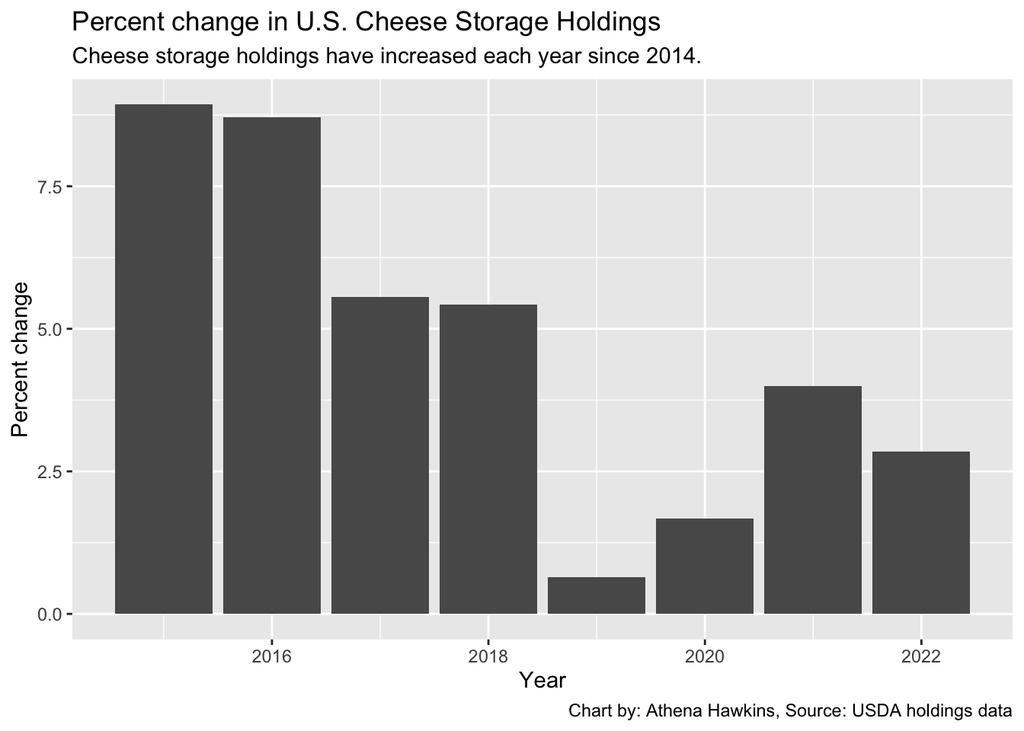

```r
percent_change_plot <- ggplot(storage_change, aes(x = year, y = pct_change)) +
  geom_col() +
  labs(title = "Percent change in U.S. Cheese Storage Holdings", subtitle = str_wrap("Cheese storage holdings have increased each year since 2014."), caption = "Chart by: Athena Hawkins, Source: USDA holdings data",
       x = "Year", y = "Percent change")

percent_change_plot
```